# R Assignment - Pizza EDA

```r
# 1. Answer each question using in words/paragraph.
# 2. DO NOT use comments inside code blocks (like here) to answer anything. Those are for notes between
# coders/yourself. They will be ignored, and not counted as answers.
# 3. Keep the line/option    knitr::opts_chunk$set(warning = F, results = "hide", message = F)
# You can temporarily turn this on/off and use other option while you are working on the homework if it helps.
# The submitted work should have this option selected instead.
# 4. All charts/graphs/tables should have appropriate captions.
# 5. You may want to use the ezids::outlierKD2 function to handle outliers
# 6. Your grade is also determined by the style. Even if you answers everything correctly, but the html does not look appealing, you will NOT get the full credits. Pay attention to the details that we mentioned in class and in previous sample RMD files. How to use #, ##, ###, ..., bold face, italics, inline codes, LaTeX, tables, ...,  {results = "asis"}, single space vs two spaces at the end of line, ... , use of colors in plots/ggplots, and so forth.
```

# HW Assignment - EDA

This pizza ingredient dataset is from data.world (@sdhilip) The variables are:

| Variable | Definition |
| --- | --- |
| brand | Pizza brand |
| id | ID |
| mois | Amount of water per 100 grams in the sample |
| prot | Amount of protein per 100 grams in the sample |
| fat | Amount of fat per 100 grams in the sample |
| ash | Amount of ash per 100 grams in the sample |
| sodium | Amount of sodium per 100 grams in the sample |
| carb | Amount of carbohydrates per 100 grams in the sample |
| cal | Amount of calories per 100 grams in the sample |

As with all your work in this class, knit the RMD file into HTML, zip it with the RMD, and submit the zip file on Blackboard.

Compose your answers using inline R code instead of using the code-block output as much as you can. Coder’s comments inside code blocks are never graded.

## Pizza Ingredient Dataset

### Question 1: Import Dataset

**Import the Pizza.csv dataset into R.**

```r
pizza = data.frame(read.csv("Pizza.csv"))
```

### Question 2: Total Number of Observations

**How many data points are there?**

There are a total of 300 data points.

You can use the `length()` or `nrow()` function.

```r
nrow(pizza)
```

[1] 300

### Question 3: Dataset Summary Statistics

**Look at the summary statistics of the dataset.**  
Use the `xkablesummary()` function?

```r
ezids::xkablesummary(pizza)
```

Table: Statistics summary.

|  | brand | id | mois | prot | fat | ash | sodium | carb | cal |
| --- | --- | --- | --- | --- | --- | --- | --- | --- | --- |
| Min | Length:300 | Min. :14003 | Min. :25.0 | Min. : 6.98 | Min. : 4.4 | Min. :1.17 | Min. :0.250 | Min. : 0.5 | Min. :2.18 |
| Q1 | Class :character | 1st Qu.:14094 | 1st Qu.:30.9 | 1st Qu.: 8.06 | 1st Qu.:14.8 | 1st Qu.:1.45 | 1st Qu.:0.450 | 1st Qu.: 3.5 | 1st Qu.:2.91 |
| Median | Mode :character | Median :24020 | Median :43.3 | Median :10.44 | Median :17.1 | Median :2.22 | Median :0.490 | Median :23.2 | Median :3.21 |
| Mean | NA | Mean :20841 | Mean :40.9 | Mean :13.37 | Mean :20.2 | Mean :2.63 | Mean :0.669 | Mean :22.9 | Mean :3.27 |
| Q3 | NA | 3rd Qu.:24110 | 3rd Qu.:49.1 | 3rd Qu.:20.02 | 3rd Qu.:21.4 | 3rd Qu.:3.59 | 3rd Qu.:0.703 | 3rd Qu.:41.3 | 3rd Qu.:3.52 |
| Max | NA | Max. :34045 | Max. :57.2 | Max. :28.48 | Max. :47.2 | Max. :5.43 | Max. :1.790 | Max. :48.6 | Max. :5.08 |

### Question 4: Histograms, Boxplots, and QQ-Plots

**Make Plots - 1**  
For sodium and calorie, make histograms, boxplots (using `ggplot()`), and QQ-plots (just regular `qqnorm()` function). Make sure all plots have appropriate titles, x- and y- labels, units on the axes if applicable. It is also much nicer to add some color to your charts instead of plain old black and white. For chart titles, if no appropriate title you can think of, just use y vs x. Don’t get mixed up (somehow I find up to half of the presentations have the wrong ones). It is NEVER x vs y. **Always y vs x**.

#Histogram Plots for Sodium and Calories

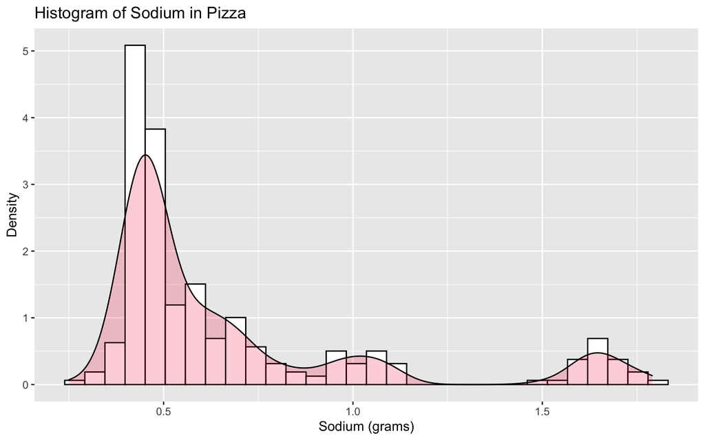

```r
#Histogram for Sodium
ggplot(pizza, aes(x=sodium)) +
 geom_histogram(aes(y=..density..), colour="black", fill="white")+
 geom_density(alpha=.2, fill="#f50041") +
 ggtitle("Histogram of Sodium in Pizza") + xlab("Sodium (grams)") + ylab("Density")
```

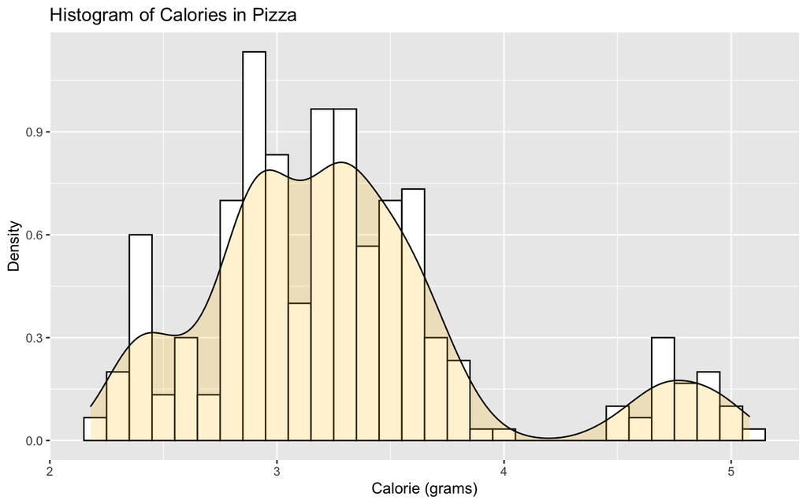

```r
#Histogram for Calorie
ggplot(pizza, aes(x=cal)) +
 geom_histogram(aes(y=..density..), colour="black", fill="white")+
 geom_density(alpha=.2, fill="#ffc400") +
 ggtitle("Histogram of Calories in Pizza") + xlab("Calorie (grams)") + ylab("Density")
```

#Boxplots for Sodium and Calories

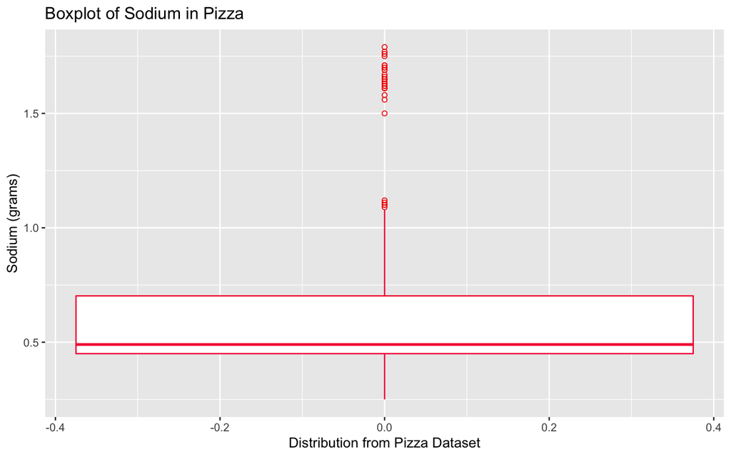

```r
#Boxplot of Sodium
ggplot(pizza, aes(y=sodium))+
  geom_boxplot(fill='white', color="#f50041", outlier.colour="#f50000", outlier.shape=1) +
  ggtitle("Boxplot of Sodium in Pizza") + xlab("Distribution from Pizza Dataset") + ylab("Sodium (grams)")
```

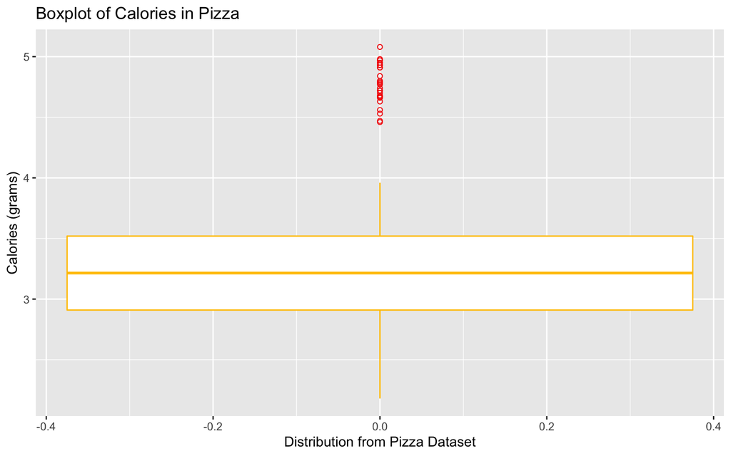

```r
#Boxplot of Calories
ggplot(pizza, aes(y=cal))+
  geom_boxplot(fill='white', color="#ffc400", outlier.colour="#f50000", outlier.shape=1) +
  ggtitle("Boxplot of Calories in Pizza") + xlab("Distribution from Pizza Dataset") + ylab("Calories (grams)")
```

#QQ-Plots for Sodium and Calories

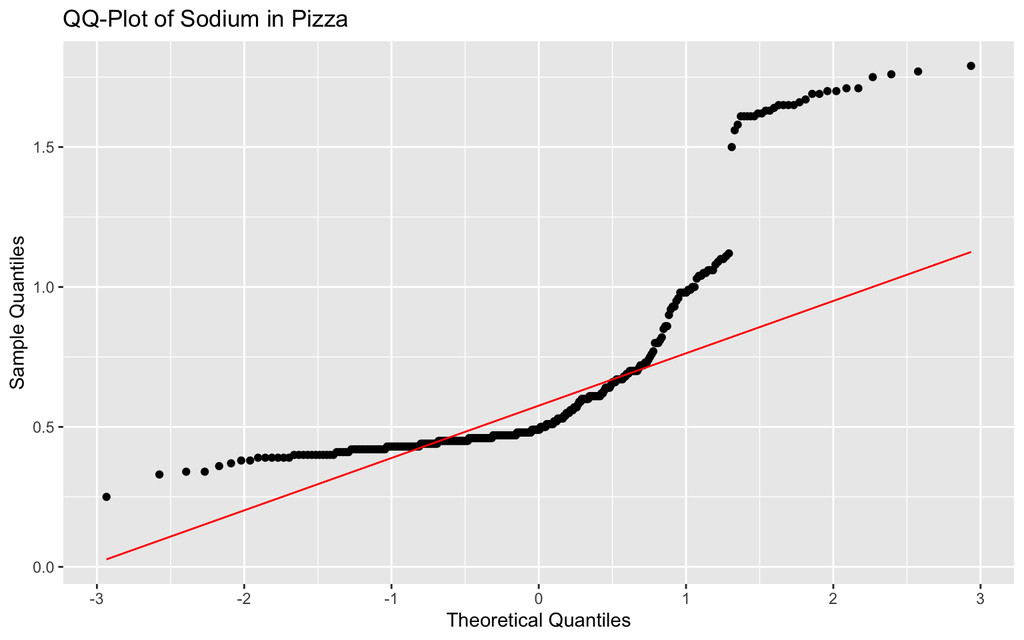

```r
#Sodium QQ-Plot
ggplot(pizza, aes(sample = sodium)) +
  stat_qq() +
  stat_qq_line(col = "red") +
  ggtitle("QQ-Plot of Sodium in Pizza") + xlab("Theoretical Quantiles") + ylab("Sample Quantiles")
```

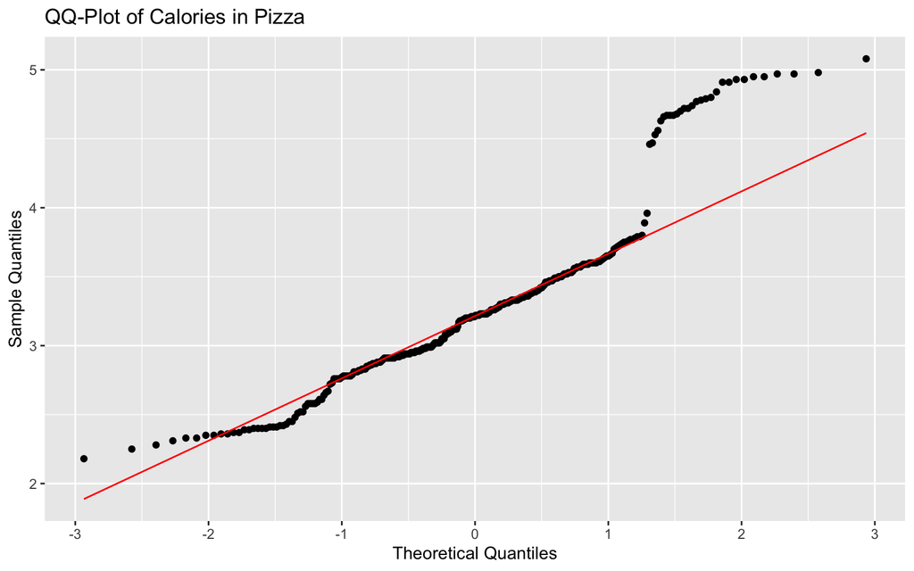

```r
#Calorie QQ-Plot
ggplot(pizza, aes(sample = cal)) +
  stat_qq() +
  stat_qq_line(col = "red") +
  ggtitle("QQ-Plot of Calories in Pizza") + xlab("Theoretical Quantiles") + ylab("Sample Quantiles")
```

### Question 5: Scatterplot - Sodium versus Calorie

**Make Plots - 2**  
Making a scatterplot (using `ggplot()`), between sodium and calorie, color by the brand. As always, give the plot appropriate title, axis labels, and make it look good.

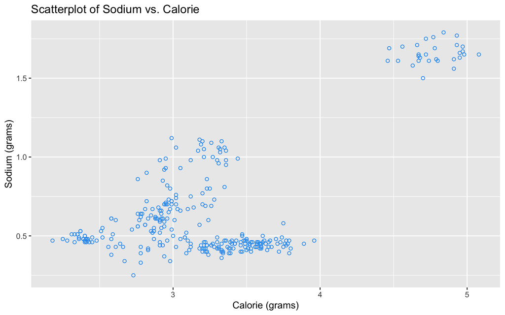

```r
ggplot(pizza, aes(x=cal, y=sodium)) + geom_point(color="#0093f5", shape=1) + ggtitle("Scatterplot of Sodium vs. Calorie") + xlab("Calorie (grams)") + ylab("Sodium (grams)")
```

### Question 6: Scatterplot - Sodium versus Calorie by Protein

**Make Plots - 3**  
Making another scatterplot (using `ggplot()`), between sodium and calorie, color by protein. What major difference do you see between this and the previous scatterplot?

The major difference between the two scatterplots is that the graph in Question 5 displays the relationship between two variables (sodium and calories) and the graph in Question 6 displays the relationship between three variables (sodium, calorie, and protein).

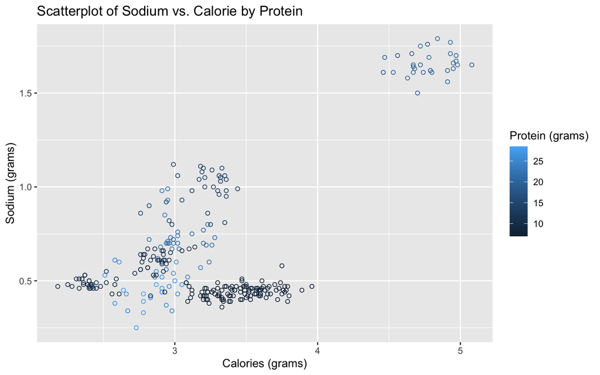

```r
ggplot(pizza, aes(x=cal, y=sodium)) + geom_point(aes(color=prot), shape=1) + ggtitle("Scatterplot of Sodium vs. Calorie by Protein") + xlab("Calories (grams)") + ylab("Sodium (grams)") + labs(col="Protein (grams)")
```

### Question 7: Scatterplot - Sodium versus Brand

**Make Plots - 4**  
This time, make a plot with sodium as y, and brand as x. (What kind of plot would you choose?)

I would have chosen to plot the data using a boxplot. This is because the x-axis contains a categorical variable and the y-axiz contians numeric variable. A boxplot would be able to plot the distribution of sodium by brand of pizza.

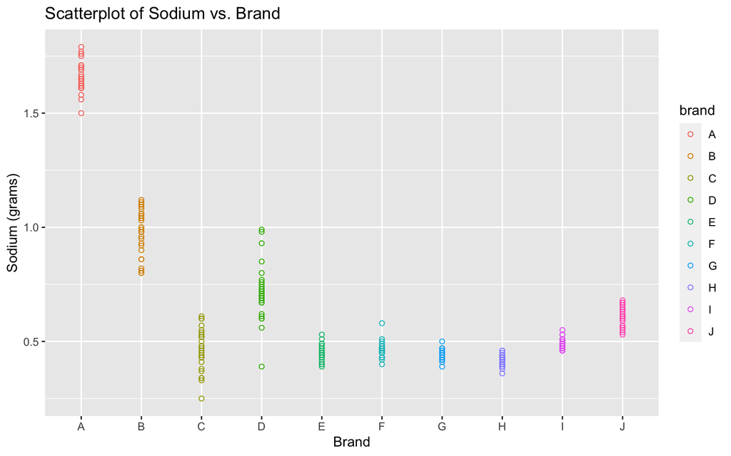

```r
ggplot(pizza, aes(x=brand, y=sodium)) + geom_point(aes(color=brand), shape=1) + ggtitle("Scatterplot of Sodium vs. Brand") + xlab("Brand") + ylab("Sodium (grams)")
```

### Question 8: Removing Outliers

**Outliers**  
Use the `ezids::outlierKD2()` function to remove the outliers for sodium, then run the function again to remove outliers on calories. Re-do the QQ-plots for these two variables. Do you see much improvements?

After removing the outliers from the sodium and calorie variables, there is some improvement in the QQ-plots for each variable. The QQ-plot of the Calories in Pizza exhibits the most improvement. This is indicated by the data points aligning more evenly with the standard normal variate, which is represented by the red line.

The QQ-Plot of Sodium in Pizza exhibits the least amount of improvement. Despite removing outliers, the sodium variable data significantly deviates from the straight line or the standard normal variate. This indicates that the data is highly skewed. However, this is a slight improvement from the original QQ-Plot of Sodium in Pizza in which the data exhibited even more deviation from the red line or standard normal variate.

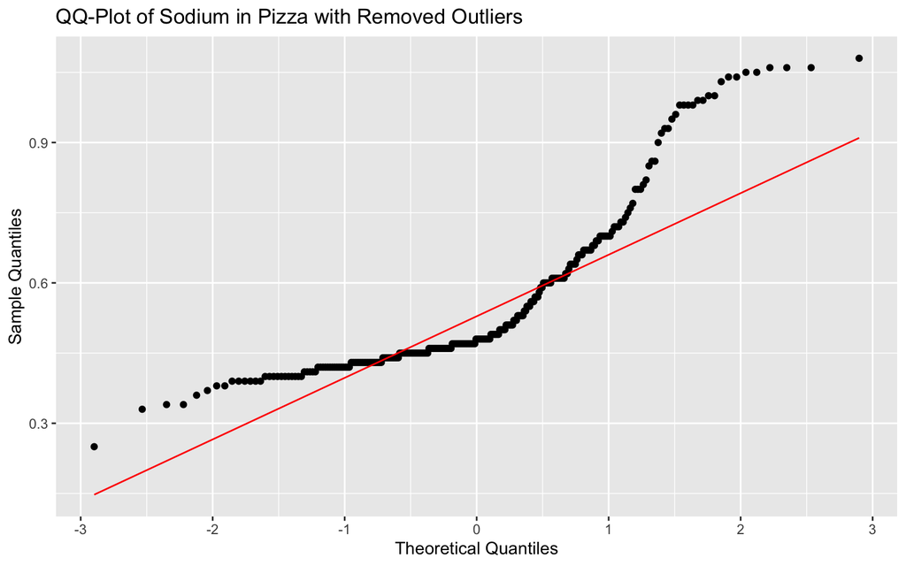

```r
mod_sodium<-ezids::outlierKD2(pizza, sodium, rm=TRUE, boxplt=FALSE, histogram=FALSE, qqplt=FALSE)

mod_cal<-ezids::outlierKD2(pizza, cal, rm=TRUE, boxplt=FALSE, histogram=FALSE, qqplt=FALSE)

#Sodium QQ-Plot
ggplot(mod_sodium, aes(sample = sodium)) +
  stat_qq() +
  stat_qq_line(col = "red") +
  ggtitle("QQ-Plot of Sodium in Pizza with Removed Outliers") + xlab("Theoretical Quantiles") + ylab("Sample Quantiles")
```

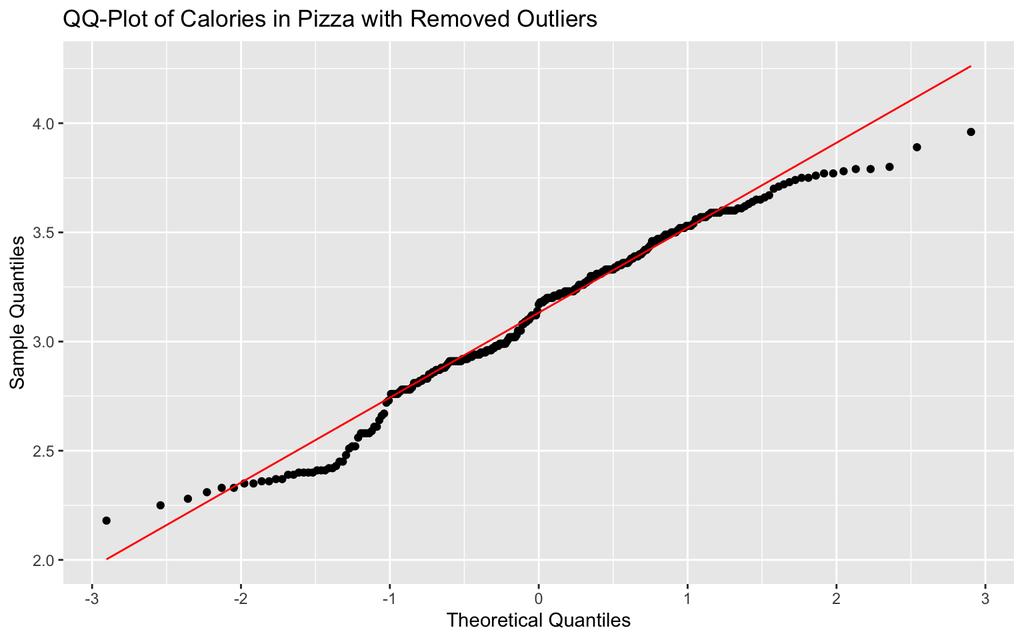

```r
#Calorie QQ-Plot
ggplot(mod_cal, aes(sample = cal)) +
  stat_qq() +
  stat_qq_line(col = "red") +
  ggtitle("QQ-Plot of Calories in Pizza with Removed Outliers") + xlab("Theoretical Quantiles") + ylab("Sample Quantiles")
```